# Лабораторная работа №2

Администрирование локальных сетей

Ибрахим Мохсейн Алькамаль

1032225432@rudn.ru

Российский университет дружбы народов

2026-02-21

# Цель работы

## Цель работы

- Получить основные навыки по начальному конфигурированию оборудования Cisco.

# выполнения работы

## Размещение устройств в логической рабочей области

- Размещены маршрутизатор Cisco 2811, коммутатор Cisco 2960-24TT и два ПК
- PC0 подключён к маршрутизатору (FastEthernet0/0)
- PC1 подключён к коммутатору (FastEthernet0/1)
- PC0: 192.168.1.10/24
- Маршрутизатор: 192.168.1.254/24
- PC1: 192.168.2.10/24
- Коммутатор (VLAN2): 192.168.2.1/24

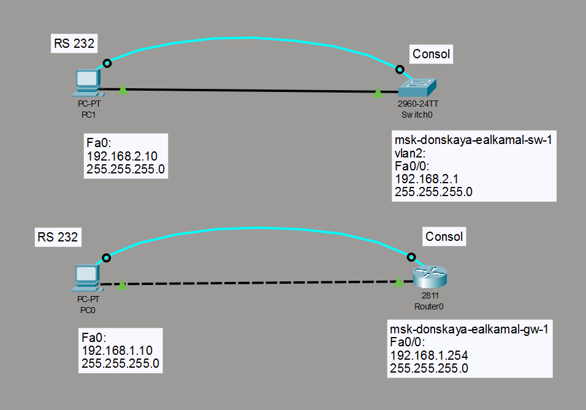

Рисунок 1: Топология сети с маршрутизатором, коммутатором и двумя ПК

## Настройка маршрутизатора (msk-donskaya-ealkamal-gw-1)

- Переход в привилегированный режим
- Задано имя узла `msk-donskaya-ealkamal-gw-1`
- Настроен FastEthernet0/0 — 192.168.1.254/24
- Интерфейс активирован (`no shutdown`)
- Настроены линии VTY и console с паролями
- Включено шифрование паролей
- Создан локальный пользователь
- Задано доменное имя
- Сгенерированы RSA-ключи
- Для VTY разрешён только SSH

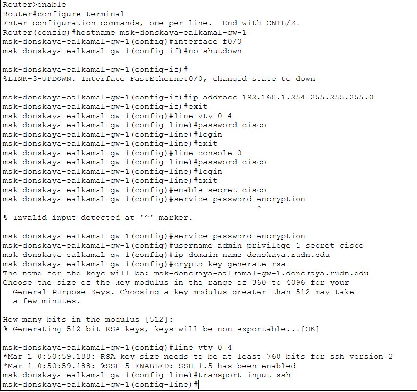

Рисунок 2: Настройка маршрутизатора и генерация RSA-ключей для SSH

## Настройка коммутатора (msk-donskaya-ealkamal-sw-1)

- Задано имя `msk-donskaya-ealkamal-sw-1`
- Настроен интерфейс VLAN2 — 192.168.2.1/24
- VLAN2 активирован
- FastEthernet0/1 переведён в access
- Порт назначен в VLAN 2
- Указан шлюз по умолчанию 192.168.2.254
- Настроены линии VTY и console с паролями
- Включено шифрование паролей
- Создан локальный пользователь
- Задано доменное имя
- Сгенерированы RSA-ключи для SSH

[figure not shown]

Рисунок 3: Настройка коммутатора, VLAN2 и параметров SSH

[figure not shown]

Рисунок 4: Настройка коммутатора, VLAN2 и параметров SSH

## Настройка IPv4-параметров с PC0 на маршрутизатор

- Проверены параметры FastEthernet0
- IP-адрес: 192.168.1.10
- Маска: 255.255.255.0
- Шлюз: 192.168.1.254
- Параметры соответствуют настройкам маршрутизатора

[figure not shown]

Рисунок 5: Настройка IPv4-параметров PC0 (FastEthernet0)

## Проверка сети с PC0 на маршрутизатор

- Выполнена команда `ping 192.168.1.254`
- Потерь пакетов нет (0% loss)
- Связность подтверждена

[figure not shown]

Рисунок 6: Результат выполнения команды ping с PC0 на маршрутизатор

- Выполнено SSH-подключение `ssh -l admin 192.168.1.254`
- Получен доступ к CLI маршрутизатора
- Подтверждена корректная настройка SSH

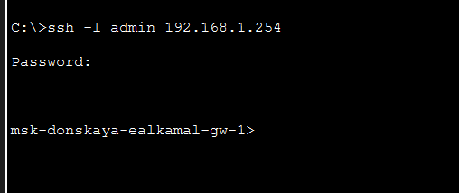

Рисунок 7: Подключение к маршрутизатору по протоколу SSH с PC0

- Выполнено консольное подключение через Terminal
- Пройдена аутентификация
- Зафиксированы сообщения об изменении состояния FastEthernet0/0

[figure not shown]

Рисунок 8: Консольное подключение к маршрутизатору через Terminal

## Настройка IPv4-параметров с PC1 на коммутатор

- Настроен FastEthernet0
- IP-адрес: 192.168.2.10
- Маска: 255.255.255.0
- Узел в одной подсети с VLAN2 (192.168.2.1/24)

[figure not shown]

Рисунок 9: Настройка IPv4-параметров PC1 (FastEthernet0)

## Проверка сети с PC1 на коммутатор

- Выполнена команда `ping 192.168.2.1`
- Передано 4 пакета, получено 3
- 1 пакет потерян при инициализации ARP
- Связность подтверждена

[figure not shown]

Рисунок 10: Результат выполнения команды ping с PC1 на коммутатор

- Выполнено SSH-подключение `ssh -l admin 192.168.2.1`
- Получен доступ к CLI коммутатора
- Подтверждена корректная настройка SSH

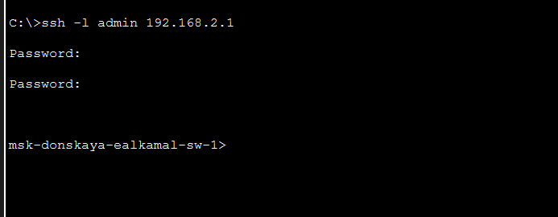

Рисунок 11: Подключение к коммутатору по протоколу SSH с PC1

- Выполнено консольное подключение через Terminal
- Пройдена аутентификация
- Зафиксированы изменения состояния FastEthernet0/1 и VLAN2

[figure not shown]

Рисунок 12: Консольное подключение к коммутатору через Terminal

# Выводы

## Выводы

- Построена простая сетевая топология
- Выполнена базовая настройка IP-адресации и VLAN
- Настроены параметры удалённого доступа (SSH)
- Проверка `ping` подтвердила работоспособность сети
- Консольный и SSH-доступ функционируют корректно
- Базовая конфигурация устройств выполнена успешно